# IHA_post_KEY

Justin Pomeranz

# Overview

This document has the answers for all IHA metrics for the time period after the dam was closed. The code to create the answer is not shown, just the results.

# Preliminaries

#### Make sure your libraries and data is loaded

```r
library(tidyverse)
library(RcppRoll)
post <- read_tsv("data/post_data.csv")
```

- Print out names of post data

```
## # A tibble: 3,652 × 7
##    date         cfs     y     m     d j_date consecutive_date
##    <date>     <dbl> <dbl> <dbl> <dbl>  <dbl>            <dbl>
##  1 1990-01-01  7430  1990     1     1      1                1
##  2 1990-01-02 11300  1990     1     2      2                2
##  3 1990-01-03 15700  1990     1     3      3                3
##  4 1990-01-04 15800  1990     1     4      4                4
##  5 1990-01-05 12000  1990     1     5      5                5
##  6 1990-01-06 14900  1990     1     6      6                6
##  7 1990-01-07  8890  1990     1     7      7                7
##  8 1990-01-08 12800  1990     1     8      8                8
##  9 1990-01-09 11900  1990     1     9      9                9
## 10 1990-01-10 12600  1990     1    10     10               10
## # ℹ 3,642 more rows
```

```
## [1] "date"             "cfs"              "y"                "m"
## [5] "d"                "j_date"           "consecutive_date"
```

### Plot your data

- It’s always a good idea to plot your data as well
- below is a simple plot of the mean daily cfs values

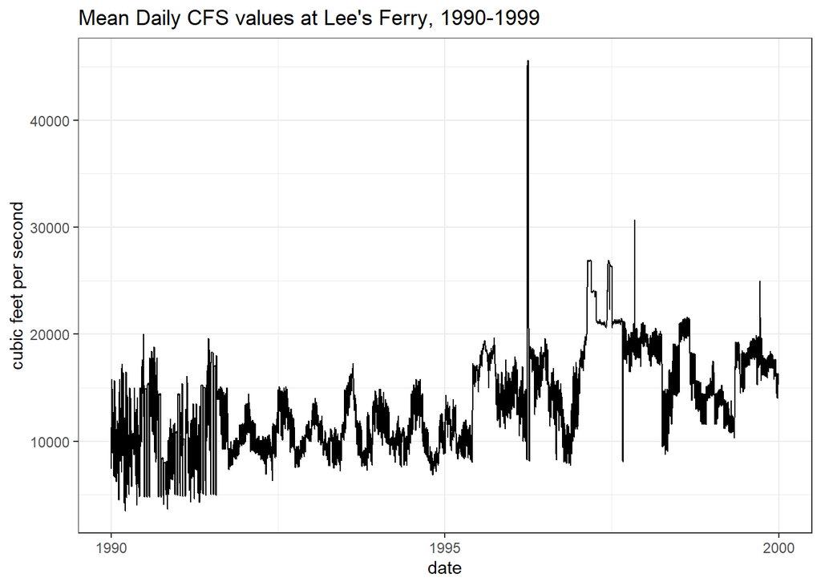

## IHA Metrics

### Group 1

- take `post` data and “group” it by month
- calculate average flow value within a month, across years
  - i.e., take all the observations from January and average them together

```
## # A tibble: 12 × 2
##        m m_mean
##    <dbl>  <dbl>
##  1     1 14042.
##  2     2 13871.
##  3     3 13517.
##  4     4 12606.
##  5     5 13176.
##  6     6 15184.
##  7     7 16356.
##  8     8 16701.
##  9     9 14620.
## 10    10 11913.
## 11    11 12332.
## 12    12 13669.
```

- in the code above, the output is a data frame with two columns:
  - `m` is the month
  - `m_mean` is short for “monthly mean”

### Calculations Group 2

#### 1-day values

```
## # A tibble: 1 × 2
##   m_min_1 m_max_1
##     <dbl>   <dbl>
## 1    7120   23040
```

#### 3-day values

```
## # A tibble: 1 × 2
##   m_min_3 m_max_3
##     <dbl>   <dbl>
## 1   8057.   22200
```

#### 7-day values

```
## # A tibble: 1 × 2
##   m_min_7 m_max_7
##     <dbl>   <dbl>
## 1   9695.  21343.
```

#### 30-day

```
## # A tibble: 1 × 2
##   m_min_30 m_max_30
##      <dbl>    <dbl>
## 1   10301.   18468.
```

#### 90-day

```
## # A tibble: 1 × 2
##   m_min_90 m_max_90
##      <dbl>    <dbl>
## 1   11536.   16834.
```

### Calculations Group 3

#### Minimum Julian dates

```
## # A tibble: 1 × 1
##   min_j_date
##        <dbl>
## 1       175.
```

[output not shown]

# Moving forward

You now have all the answers for part 1. As part of the assignment, you need to submit your R scripts showing how you calculated the metrics. However, if you get stuck or are unsure how to proceed, between the tutorial and this key, you have all the numbers to calculate the Deviation Magnitude and the Percent Deviation.